# Preprocessing merged data

Julian Barg

April 17, 2019

```r
library(tidyverse)
```

## Read data

```r
library(feather)
recalls_matched <- read_feather("../preprocessed/recalls_matched 2019-04-21.feather")

personnel <- select(recalls_matched, gvkey, name, execid, year, personnel_is_ceo, personnel_full_name)

glimpse(personnel)
```

```
## Observations: 2,525
## Variables: 6
## $ gvkey               <chr> "002184", "002184", "002184", "002184", "002…
## $ name                <chr> "Best Buy Co Inc", "Best Buy Co Inc", "Best …
## $ execid              <chr> "06175", "06175", "06175", "06175", "13283",…
## $ year                <dbl> 2006, 2007, 2008, 2009, 2006, 2007, 2006, 20…
## $ personnel_is_ceo    <lgl> TRUE, TRUE, TRUE, FALSE, FALSE, FALSE, FALSE…
## $ personnel_full_name <chr> "Bradbury H. Anderson", "Bradbury H. Anderso…
```

## Check the data

### Check for duplicates

Are there duplicate entries, for instance in a year if an employee becomes a CEO?

```r
colnames(personnel)
```

```
## [1] "gvkey"               "name"                "execid"
## [4] "year"                "personnel_is_ceo"    "personnel_full_name"
```

```r
nrow(personnel)
```

```
## [1] 2525
```

```r
nrow(unique(personnel[ ,1:4]))
```

```
## [1] 2525
```

We do not have to worry about duplicate entries.

### Make sure every execid only refers to one person.

```r
personnel %>%
  select(execid, personnel_full_name) %>%
  group_by(execid) %>%
  summarize(n = n_distinct(personnel_full_name)) %>%
  ungroup() %>%
  select(n) %>%
  table(.)
```

```
## .
##   1
## 571
```

It appears all 571 execids all only refer to one person.

### See if individuals changed employees

```r
personnel %>%
  select(execid, gvkey) %>%
  group_by(execid) %>%
  mutate(n = n_distinct(gvkey)) %>%
  # Selecting the first row from each group (individuals) so we can easily see how many employees changed employers out of the total number of tracked individual.
  filter(row_number() == 1) %>%
  ungroup() %>%
  select(n) %>%
  table(.)
```

```
## .
##   1   2   3
## 557  13   1
```

It seems a few individuals have worked for different employees at different points in time.

## Create personnel exit flag

```r
personnel <- personnel %>%
  group_by(execid, gvkey) %>%
  arrange(execid, year, gvkey) %>%
  mutate(exit = row_number() == n())
```

```r
subset(personnel, execid %in% unique(personnel$execid)[1:3], select = c("gvkey", "name", "execid", "exit"))
```

```
## # A tibble: 23 x 4
## # Groups:   execid, gvkey [3]
##    gvkey  name                  execid exit
##    <chr>  <chr>                 <chr>  <lgl>
##  1 025338 Bed Bath & Beyond Inc 00117  FALSE
##  2 025338 Bed Bath & Beyond Inc 00117  FALSE
##  3 025338 Bed Bath & Beyond Inc 00117  FALSE
##  4 025338 Bed Bath & Beyond Inc 00117  FALSE
##  5 025338 Bed Bath & Beyond Inc 00117  FALSE
##  6 025338 Bed Bath & Beyond Inc 00117  FALSE
##  7 025338 Bed Bath & Beyond Inc 00117  FALSE
##  8 025338 Bed Bath & Beyond Inc 00117  FALSE
##  9 025338 Bed Bath & Beyond Inc 00117  FALSE
## 10 025338 Bed Bath & Beyond Inc 00117  TRUE
## # … with 13 more rows
```

## Get turnover

### Calculate number of employees tracked each year

```r
personnel <- personnel %>%
  group_by(gvkey, year) %>%
  mutate(n_employees = n())
table(personnel$n_employees)
```

```
##
##    3    4    5    6    7    8    9   10   11
##    9    4 1190  774  350  112   45   30   11
```

### Calculate how many of the tracked employees exit

```r
personnel <- personnel %>%
  group_by(gvkey, year) %>%
  mutate(n_exits = sum(exit==TRUE)) %>%
  ungroup()
table(personnel$n_exits)
```

```
##
##    0    1    2    3    4    5    6    7    8
## 1005  666  380  134   46  151   82   45   16
```

### Calculate turnover

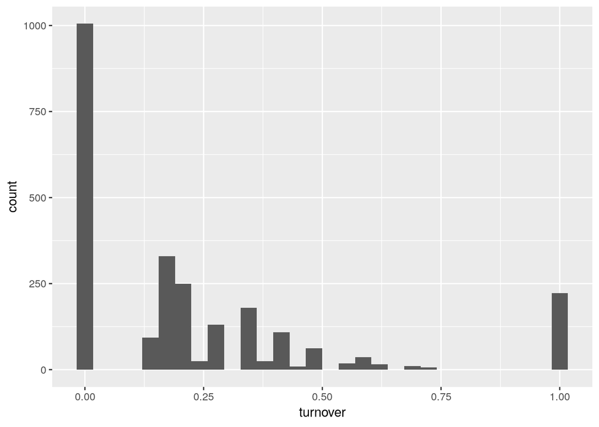

```r
personnel$turnover <- personnel$n_exits / personnel$n_employees

personnel %>%
  ggplot(aes(x=turnover)) +
  geom_histogram()
```

```r
nrow(personnel)
```

```
## [1] 2525
```

```r
nrow(personnel[personnel$turnover == 0, ])
```

```
## [1] 1005
```

```r
nrow(personnel[personnel$turnover == 1, ])
```

```
## [1] 223
```

We will look at this data again later, when we have retained only company and year level (and not employee level).

## See CEO change

### Are there years with two CEOs for one company?

```r
personnel %>%
  filter(personnel_is_ceo == TRUE) %>%
  group_by(gvkey, year) %>%
  mutate(n = n()) %>%
  ungroup() %>%
  select(n) %>%
  table(.)
```

```
## .
##   1
## 444
```

There are not.

### Is there a CEO entry for each company-year observation?

```r
personnel %>%
  group_by(gvkey, year) %>%
  # We take advantage of the fact that a TRUE also has an integer value of one in arithmetic operations.
  summarize(ceo_found = max(personnel_is_ceo)) %>%
  ungroup() %>%
  select(ceo_found) %>%
  table(.)
```

```
## .
##   1
## 444
```

Fortunately, the CEO has been identified for every year.

### CEO exit

We can simply use the exit flag for CEOs as an indicator of CEO change.

```r
personnel <- personnel %>%
  mutate(ceo_exit = (personnel_is_ceo == TRUE) & (exit == TRUE)) %>%
  group_by(gvkey, year) %>%
  # Again, we take advantage of the fact that a TRUE also has an integer value of one in arithmetic operations.
  mutate(ceo_exit = as.logical(max(ceo_exit))) %>%
  ungroup()
glimpse(personnel)
```

```
## Observations: 2,525
## Variables: 11
## $ gvkey               <chr> "025338", "025338", "025338", "025338", "025…
## $ name                <chr> "Bed Bath & Beyond Inc", "Bed Bath & Beyond …
## $ execid              <chr> "00117", "00117", "00117", "00117", "00117",…
## $ year                <dbl> 2006, 2007, 2008, 2009, 2010, 2011, 2012, 20…
## $ personnel_is_ceo    <lgl> FALSE, FALSE, FALSE, FALSE, FALSE, FALSE, FA…
## $ personnel_full_name <chr> "Warren Eisenberg", "Warren Eisenberg", "War…
## $ exit                <lgl> FALSE, FALSE, FALSE, FALSE, FALSE, FALSE, FA…
## $ n_employees         <int> 5, 5, 5, 5, 5, 5, 5, 7, 7, 7, 7, 8, 5, 5, 5,…
## $ n_exits             <int> 0, 0, 0, 0, 0, 0, 0, 0, 0, 2, 2, 3, 0, 0, 1,…
## $ turnover            <dbl> 0.0000000, 0.0000000, 0.0000000, 0.0000000, …
## $ ceo_exit            <lgl> FALSE, FALSE, FALSE, FALSE, FALSE, FALSE, FA…
```

## Convert to company-year

We have obtained all data we wanted from the personnel records. Because we always used group_by operations, all newly generated variables should be constant within every company-year observation.

```r
company_year <- unique(select(personnel, gvkey, name, year, n_employees, n_exits, turnover, ceo_exit))

nrow(company_year)
```

```
## [1] 444
```

```r
nrow(unique(select(company_year, gvkey, year)))
```

```
## [1] 444
```

### Plot turnover again

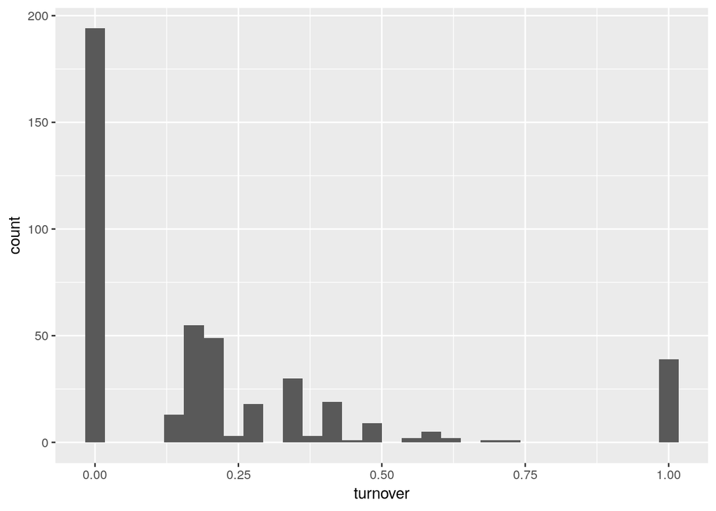

```r
company_year %>%
  ggplot(aes(x=turnover)) +
  geom_histogram()
```

It looks very similar to the plot we received when plotting by personnel.

### Re-merge recalls

```r
colnames(recalls_matched)
```

```
##  [1] "gvkey"               "name"                "SIC"
##  [4] "NAICS"               "GICS_group"          "GICS_industry"
##  [7] "GICS_sector"         "GICS_subindustry"    "execid"
## [10] "year"                "personnel_full_name" "personnel_is_ceo"
## [13] "name_clean"          "recalls"
```

```r
merge_data <- recalls_matched %>%
  select(gvkey, year, recalls) %>%
  unique()

nrow(merge_data)
```

```
## [1] 444
```

```r
nrow(company_year)
```

```
## [1] 444
```

```r
company_year <- full_join(company_year, merge_data, by=c("gvkey", "year"))
nrow(company_year)
```

```
## [1] 444
```

## Save to .feather

```r
feather::write_feather(company_year, paste0("../preprocessed/company_year ", Sys.Date(), ".feather"))
```

## Take a quick look at the results

```r
glimpse(company_year)
```

```
## Observations: 444
## Variables: 8
## $ gvkey       <chr> "025338", "025338", "025338", "025338", "025338", "0…
## $ name        <chr> "Bed Bath & Beyond Inc", "Bed Bath & Beyond Inc", "B…
## $ year        <dbl> 2006, 2007, 2008, 2009, 2010, 2011, 2012, 2013, 2014…
## $ n_employees <int> 5, 5, 5, 5, 5, 5, 5, 7, 7, 7, 7, 8, 5, 5, 5, 5, 5, 5…
## $ n_exits     <int> 0, 0, 0, 0, 0, 0, 0, 0, 0, 2, 2, 3, 0, 0, 1, 1, 0, 0…
## $ turnover    <dbl> 0.0000000, 0.0000000, 0.0000000, 0.0000000, 0.000000…
## $ ceo_exit    <lgl> FALSE, FALSE, FALSE, FALSE, FALSE, FALSE, FALSE, FAL…
## $ recalls     <dbl> 0, 0, 0, 0, 1, 2, 4, 2, 2, 4, 0, 0, 0, 0, 0, 0, 0, 0…
```

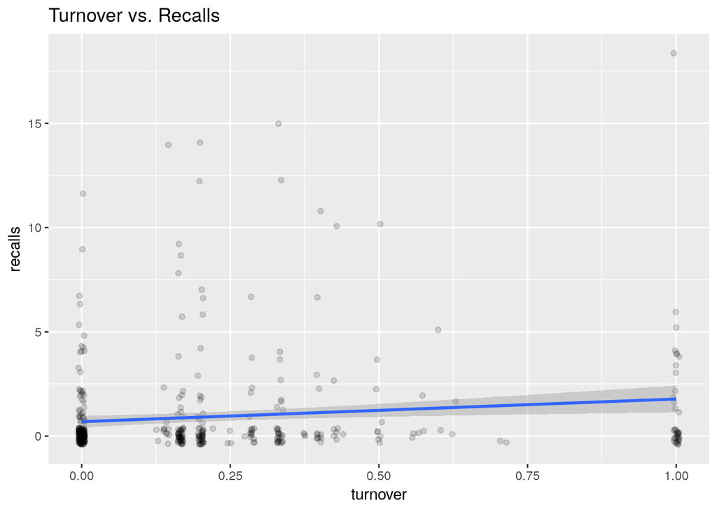

```r
company_year %>%
  ggplot(aes(x=turnover, y=recalls)) +
  geom_jitter(alpha=0.15) +
  labs(title = "Turnover vs. Recalls") +
  geom_smooth(method="lm")
```

Let’s plot only observations with variance (with nonzero observations of recalls).

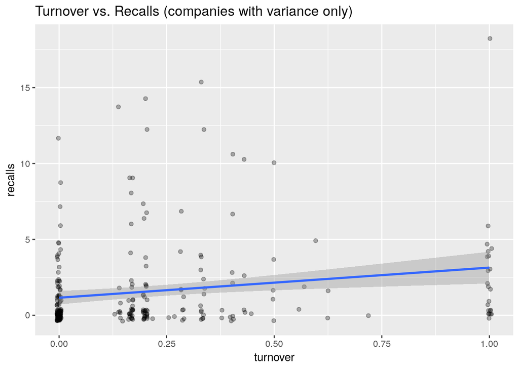

```r
company_year %>%
  group_by(gvkey) %>%
  mutate(n = max(recalls)) %>%
  ungroup() %>%
  filter(n > 0) %>%
    ggplot(aes(x=turnover, y=recalls)) +
    geom_jitter(alpha=0.3) +
    labs(title = "Turnover vs. Recalls (companies with variance only)") +
    geom_smooth(method="lm")
```

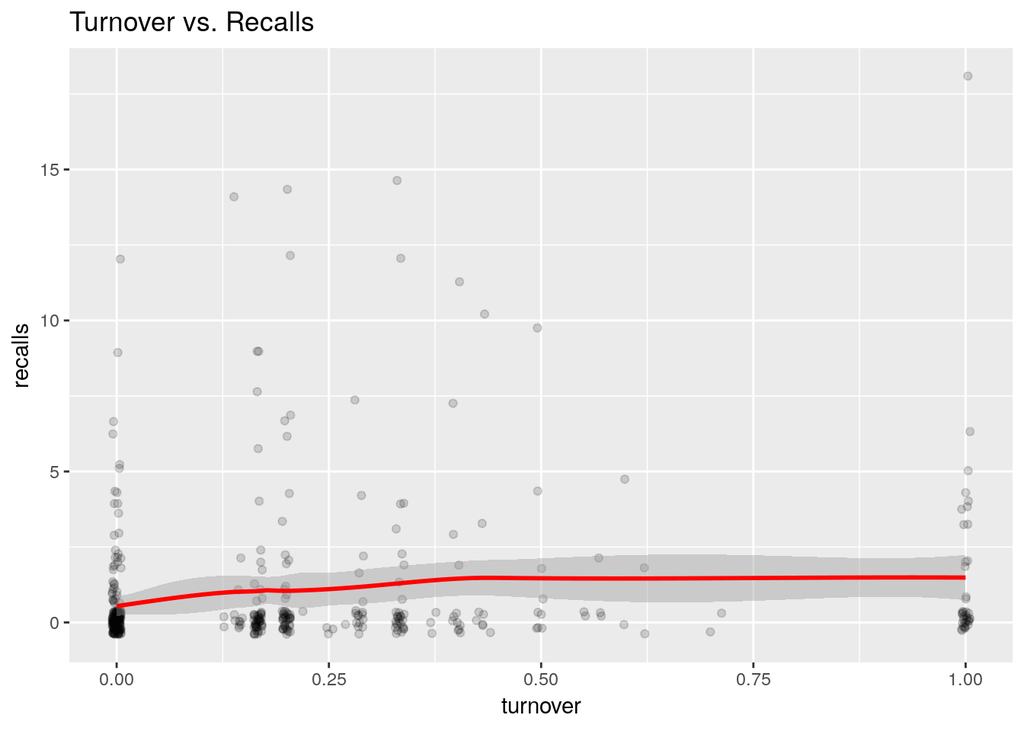

```r
company_year %>%
  ggplot(aes(x=turnover, y=recalls)) +
  geom_jitter(alpha=0.15) +
  labs(title = "Turnover vs. Recalls") +
  geom_smooth(method="loess", color="red")
```

Let’s plot only observations with variance (with nonzero observations of recalls).

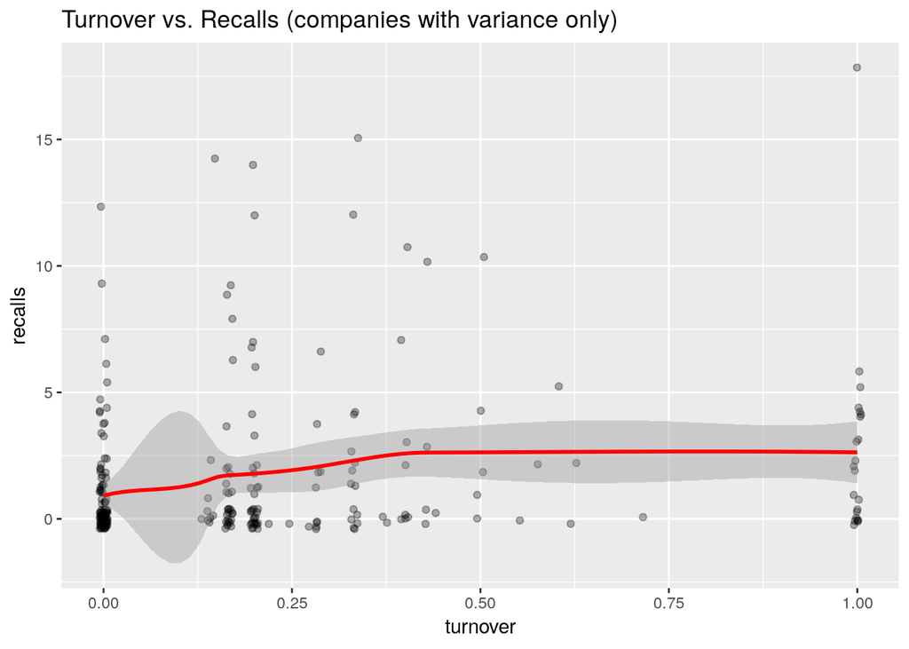

```r
company_year %>%
  group_by(gvkey) %>%
  mutate(n = max(recalls)) %>%
  ungroup() %>%
  filter(n > 0) %>%
    ggplot(aes(x=turnover, y=recalls)) +
    geom_jitter(alpha=0.3) +
    labs(title = "Turnover vs. Recalls (companies with variance only)") +
    geom_smooth(method="loess", color="red")
```